# Anoressia Nervosa

Arianna Ruggiero, Gianluca Tori

14/6/2025

#### Contesto

Si vuole valutare se è possibile individuare i segni precoci di disfunzione articolare o muscolare caratteristici delle fasi iniziali di anoressia nervosa in strutture che non consentono le misurazioni di prova fisica utilizzando i parametri bioimpedenziometrici e altri marker clinici indiretti. Un’associazione tra i parametri di forza fisica e funzionalità motoria e i parametri BIA e marker clinci indiretti sarebbe potenzialmente utile nei centri sprovvisti di ergometria.  
Si vuole quindi dimostrare che BIA e altri marker clinici indiretti e i parametri di forza muscolare e funzionalità motoria migliorano o peggiorano in parallelo e identificare quali marker clinici indiretti anticipano (o riflettono) il recupero funzionale.

Il nostro campione ha un totale di 23 osservazioni e 123 variabili.  
Numero di pazienti con anoressia nervosa: 21  
Numero di pazienti con bulimia nervosa: 2  
Non si considerano i pazienti con bulimia nervosa. Si rimuovono le seguenti colonne, al fine di non avere informazioni ridondanti e inoltre alcune rappresentano solo un calcolo intermedio usato per derivare altri indici:  
h2 –> altezza al quadrato  
data ricovero  
data_T0  
data_T1  
data_T2  
FFM, FFMp → si preferisce tenere FFMI perchè è più accurato, corregge in base alla statura, distingue soggetti apparentemente normopeso ma con massa magra ridotta

Si crea invece la variabile relativa al tempo, con modalità T0, T1 e T2 per il formato lungo

| Tipologia variabile | variabile |
| --- | --- |
| **covariate fisse nel tempo** | patologia |
|  | sintomo 1 |
|  | sintomo 2 |
|  | arto dominante |
|  | altezza |
|  | sesso |
|  | età |
| **covariate tempo dipendenti** | peso_T0, peso_T1, peso_T2 |
|  | BMI_T0, BMI_T1, BMI_T2 |
|  | mkcal_T0, mkcal_T1, mkcal_T2 |
|  | variazmenu_T0, variazmenu_T1, variazmenu_T2 |
| **Marker clinici indiretti a T0, T1, T2** | rq → quoziente respiratorio |
|  | rmr → metabolismo basale o a riposo, quantità minima di energia di cui l’organismo ha bisogno per rimanere in vita |
|  | vo2 max → volume di O2 consumata in un minuto durante l’attività fisica molto intensa |
|  | Rx_ohm → resistenza |
|  | Xc_ohm → reattanza |
|  | FM → massa grassa |
|  | FMp → % massa grassa |
|  | FFMI → indice di massa magra normalizzato |
|  | TBW → acqua corporea totale |
|  | TBWp → % acqua corporea totale |
|  | ECW → acqua extracellulare |
|  | ECWp → % acqua extracellulare |
|  | ICW acqua intracellulare |
|  | ICWp % acqua intracellulare |
|  | BCM → massa cellulare corporea |
|  | pha → integrità delle membrane cellulari |
|  | BCMI → massa cellulare corporea in rapporto alla statura |
| **parametri di forza fisica e funzionalità motoria a T0, T1, T2** | sx1, sx2, sx3, dx1, dx2, dx3 → 3 prove di forza arti superiori |
|  | mediasx, mediadx → media prove di forza arti superiori |
|  | dssx, dsdx → dev standard prove di forza arti superiori |
|  | situptest |
|  | squattest |
|  | chairstandtest |
|  | sitreachtest |

Il campione ha un totale di 23 osservazioni e 116 variabili.

#### Letteratura

- Un **valore basso** di pha riflette un cattivo stato nutrizionale e muscolare, tipico dei primi stati di anoressia, un angolo di fase elevato invece è associato ad una maggiore massa muscolare e ad una migliore salute cellulare
- Un **rapporto elevato** di ECW/ICW indica ritenzione cellulare e quindi segno di squilibrio
- Un **valore basso** di FFMI indica una minore resistenza muscolare e forza fisica
- Un **valore basso** di BCM indica il rischio di debolezza muscolare
- Un **valore basso** di RMR indica un adattamento metabolico da restrizione calorica cronica
- Un **valore basso** di VO2 indica una ridotta capacità dell’organismo di utilizzare ossigeno per l’attività fisica

### Analisi esplorativa

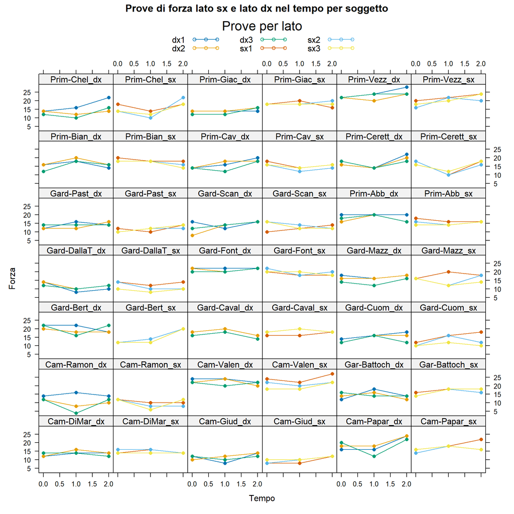

Il grafico sopra mostra l’andamento della forza nel tempo (3 punti temporali) su entrambi i lati (dx = destro, sx = sinistro) per ciascun soggetto. Per ogni soggetto si hanno due pannelli, uno per ogni lato del corpo. Alcuni soggetti mostrano aumenti marcati nel tempo, altri mostrano una forza costante nel tempo. In alcuni casi, un lato è sistematicamente più forte o mostra un andamento diverso.

Il grafico sottostante mostra la forza media per ciascun soggetto, distinta per lato del corpo. In molti pazienti il lato destro (dx) presenta valori medi superiori al lato sinistro, indicando una possibile dominanza funzionale e si può anche osservare un’ampia variabilità tra soggetti.

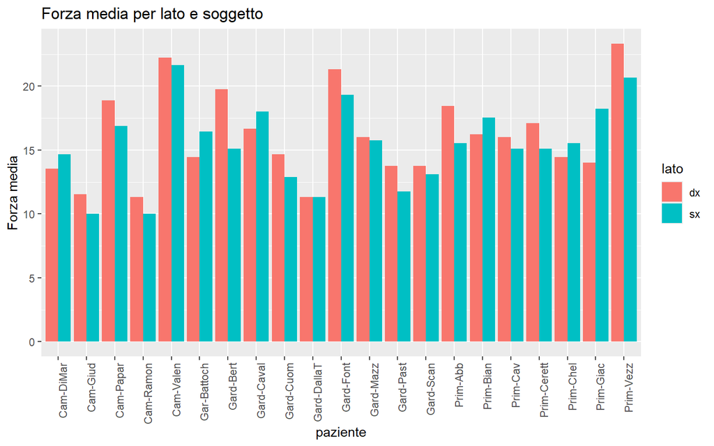

### Lattice plot per i test di performance fisica

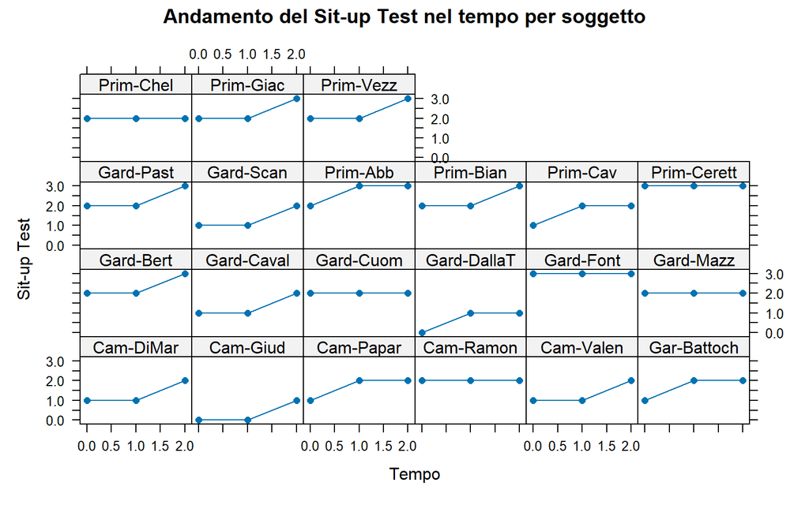

[figure not shown]

[figure not shown]

[figure not shown]

Il sit-and-reach ha dinamiche diverse dagli altri, riflettendo più la flessibilità che la forza.

## Relazioni bivariate tra marcatori clinici e test di performance

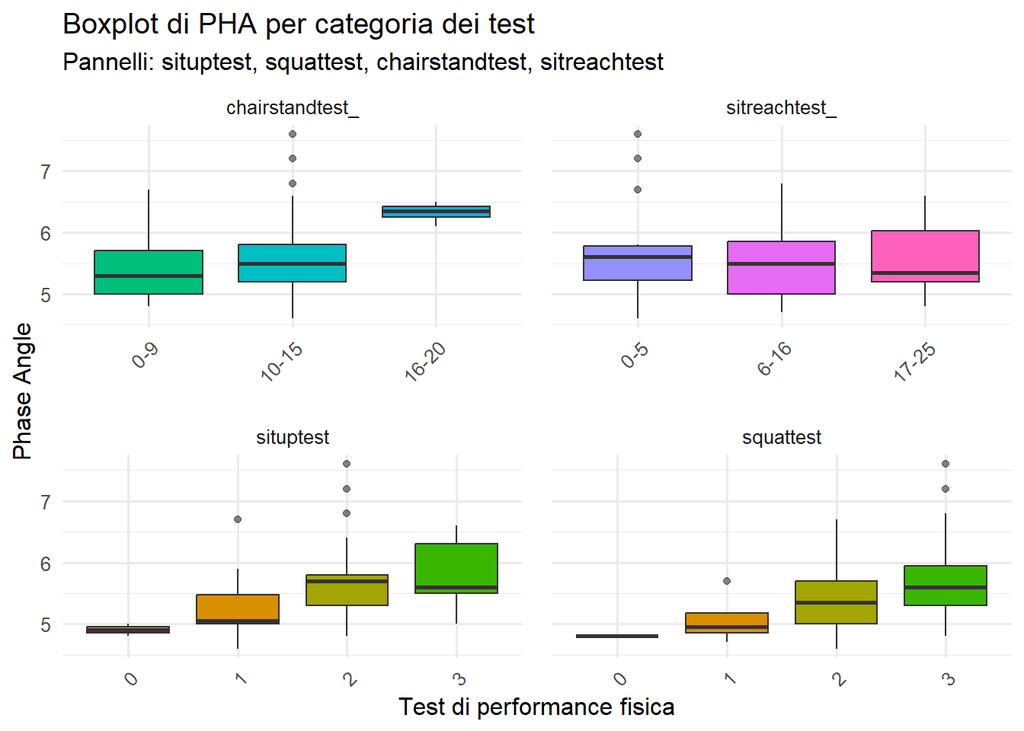

Il phase angle è un marker della qualità e integrità della massa cellulare, oltre che della funzione della membrana. Un valore più alto è associato a uno stato nutrizionale e muscolare migliore. I test di performance, invece, valutano direttamente la funzionalità fisica.

Se il PHA mostra una buona correlazione con i test di forza e resistenza (come sit-up, squat e chair stand), questo parametro potrebbe rappresentare un marker oggettivo e meno dipendente dallo sforzo per monitorare lo stato muscolare e funzionale.

Per la flessibilità, invece, il PHA sembra meno predittivo, confermando che potrebbe essere un indicatore più specifico di integrità muscolare piuttosto che di altre componenti della performance fisica.

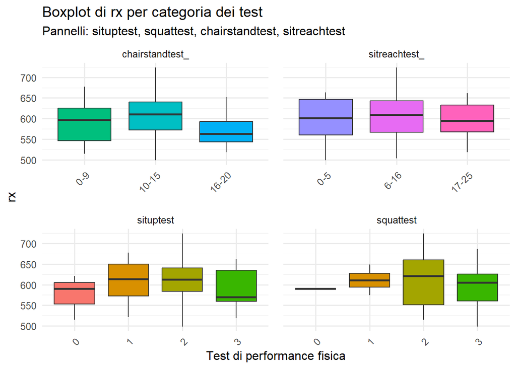

In questo grafico osserviamo la resistenza (Rₓ), parametro bioelettrico inversamente legato alla quantità di massa magra e all’idratazione cellulare, suddivisa per categorie di performance ai diversi test fisici (chair stand, sit-and-reach, sit-up e squat test). A differenza del phase angle, qui non emerge una relazione chiara tra Rₓ e le categorie di performance. In alcuni test, come il chair stand, la resistenza tende ad aumentare leggermente nelle categorie intermedie e poi a ridursi nelle categorie più alte, senza un trend costante. Nel sit-and-reach test, la distribuzione di Rₓ resta pressoché stabile tra le diverse categorie di flessibilità.

La resistenza riflette soprattutto la quantità di acqua corporea e di massa magra: valori più alti indicano minore conduttività, quindi minore massa magra o maggiore resistenza del tessuto. Nei pazienti con anoressia nervosa, dove la riduzione della massa muscolare è una caratteristica centrale, ci saremmo attesi un decremento progressivo della resistenza con l’aumentare della performance fisica. Tuttavia, i dati mostrano un quadro più eterogeneo. Ciò suggerisce che la resistenza da sola non cattura in modo diretto le variazioni funzionali legate alla performance.

Nei boxplot di confronto con Chair stand test e sit-up test le mediane di Rₓ oscillano ma non seguono un andamento progressivo chiaro. Nel boxplot di confronto con Squat test si osserva una variabilità molto elevata, con distribuzioni ampie che rendono difficile identificare un trend.

Questi risultati indicano che la resistenza (Rₓ) da sola non sembra un buon surrogato dei test di performance fisica. Mentre il phase angle aveva mostrato un parallelismo con la forza e la resistenza muscolare, la resistenza appare meno sensibile e più influenzata da altri fattori (idratazione, stato elettrolitico, variabilità individuale).

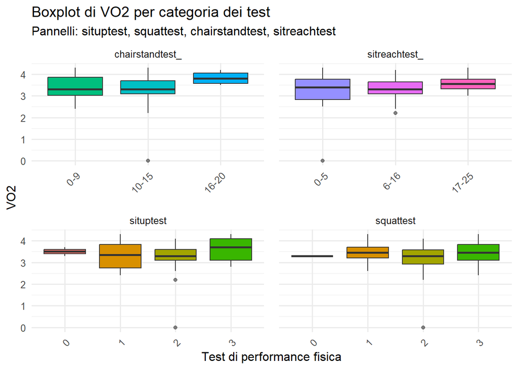

Si può osservare che:

Squat test: la tendenza all’aumento non è molto evidente, con distribuzioni ampie nelle categorie intermedie.

Sit-and-reach test: anche qui il VO₂ aumenta leggermente nelle categorie superiori, ma la progressione è meno marcata, coerente con il fatto che il VO₂ (e il PHA) riflettono soprattutto la componente muscolare e metabolica più che la flessibilità.

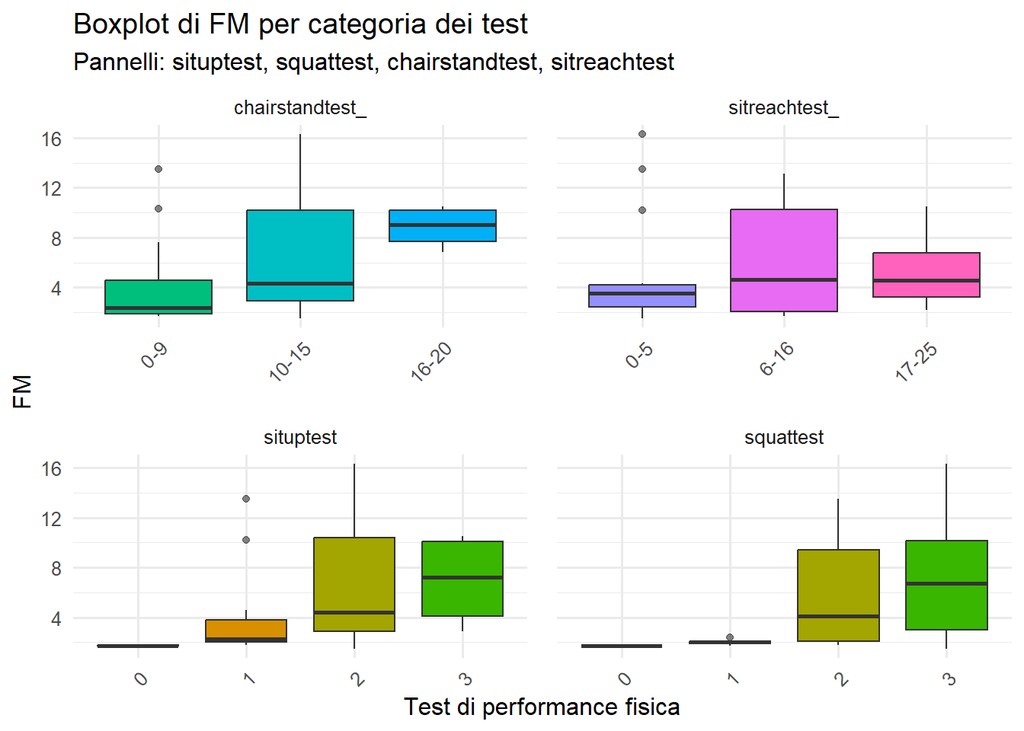

Nei pazienti con anoressia nervosa, la FM è generalmente ridotta. I risultati suggeriscono che una maggiore FM può associarsi a migliori performance nei test che coinvolgono forza e resistenza, riflettendo un miglior bilancio energetico e nutrizionale, Tuttavia, la forte variabilità osservata indica che la FM da sola non è un indicatore specifico della capacità funzionale: individui con valori simili di FM possono avere performance molto diverse. Nello specifico, nella relazione tra FM e - Chair stand test: FM aumenta in maniera evidente nelle categorie più alte, ma la variabilità nelle categorie intermedie è molto ampia.

- Sit-up test: trend simile, con FM più elevata tra i soggetti nelle categorie 2 e 3, ma anche qui la dispersione dei dati è notevole.
- Squat test: andamento crescente, anche se i boxplot mostrano una forte eterogeneità intra-categoria.
- Sit-and-reach test: non emerge un chiaro legame fra FM e performance, coerentemente con la natura del test che valuta flessibilità e non forza muscolare.

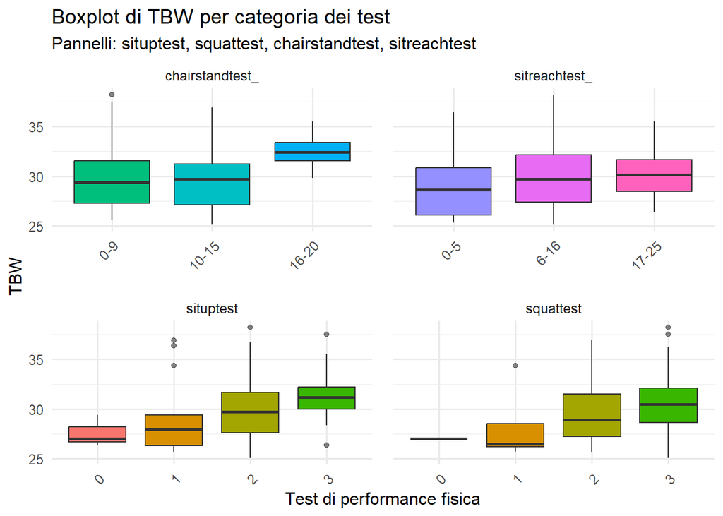

La TBW riflette in larga parte la massa magra, poiché l’acqua è contenuta principalmente nei tessuti muscolari e metabolicamente attivi. Nei pazienti con anoressia nervosa, la riduzione della massa muscolare si accompagna a una riduzione della TBW.

nello specifico, la relazione tra TBW e - Chair stand test: andamento chiaro, con un incremento progressivo della TBW nelle categorie più alte.

- Sit-up test: pattern simile, con valori di TBW più elevati per chi raggiunge i punteggi maggiori, anche se con una variabilità interna ampia.
- Squat test: la stessa tendenza si conferma, con un aumento della TBW nei livelli più alti di performance.
- Sit-and-reach test: andamento meno lineare, coerente con la natura del test che non dipende direttamente dalla massa e dall’idratazione muscolare.

Questo grafico mostra che la TBW segue in parte le variazioni di performance fisica, soprattutto nei test muscolari. Ciò suggerisce che la TBW potrebbe essere utilizzata come marker clinico complementare, utile a monitorare i pazienti in maniera meno dipendente dalla motivazione e dalla collaborazione necessaria nei test fisici. Tuttavia, la TBW da sola non è sufficientemente specifica, non riflette aspetti qualitativi della funzione muscolare come invece fa il PHA.

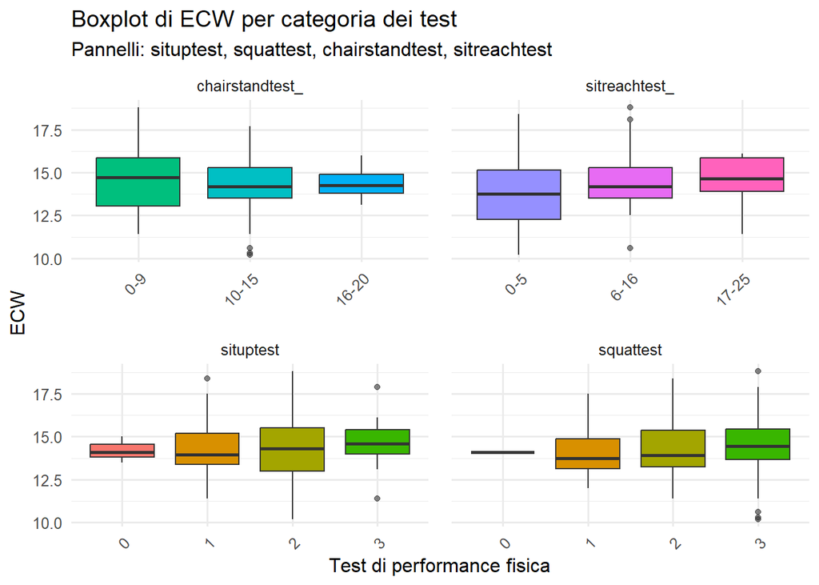

Non si osserva una chiara relazione tra ECW e performance fisica: la ECW non sembrerebbe un marker specifico della funzione muscolare. nello specifico, la relazione tra ECW e

- Chair stand test: le mediane di ECW sono piuttosto simili tra le categorie, con una lieve riduzione della variabilità nelle performance più alte.
- Sit-and-reach test: distribuzioni sovrapponibili, senza indicazioni di una relazione sistematica.
- Sit-up test: lieve tendenza all’aumento nelle categorie più alte, ma con dispersione ampia che rende difficile interpretare un trend netto.
- Squat test: andamento simile, con incrementi leggeri ma non lineari.

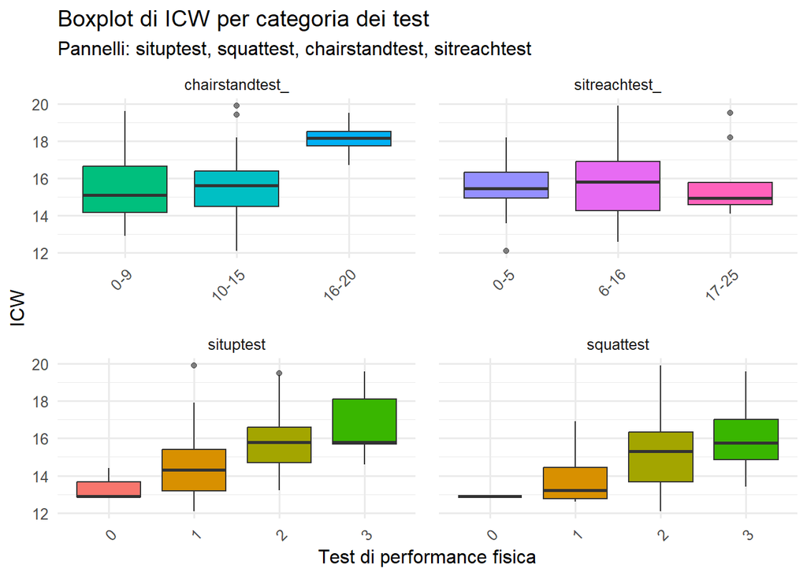

Nei test di forza e resistenza (chair stand, sit-up, squat) emerge una tendenza positiva: i soggetti che appartengono alle categorie di performance più elevate presentano valori medi di ICW più alti. Nel sit-and-reach test (flessibilità), invece, la relazione non appare altrettanto marcata, con distribuzioni sovrapponibili e una maggiore variabilità tra le categorie.

Questi dati indicano che la ICW potrebbe rappresentare un marcatore clinico promettente per affiancare o, in parte, sostituire i test di performance fisica, soprattutto per la valutazione della forza e della resistenza muscolare. Tuttavia, come tutte le analisi bivariate esplorative, si tratta di associazioni preliminari che dovranno essere confermate con approcci multivariati e analisi inferenziali.

Queste analisi si limitano a descrivere l’associazione tra ciascun test di performance fisica e un singolo parametro clinico (PHA, Rx o VO₂). Non tengono conto della correlazione tra più variabili (ad esempio età, BMI, durata della malattia, stato idrico o altre misure cliniche). Non forniscono ancora evidenza inferenziale: i boxplot permettono di visualizzare andamenti e tendenze, ma non consentono di stabilire relazioni causali o significative dal punto di vista statistico senza ulteriori modelli o test.

## Analisi delle componenti principali

La PCA consiste nella trasformazione lineare delle variabili originarie in un insieme di componenti principali, un numero inferiore rispetto a quello iniziale, che spiegano la massima varianza possibile dei dati, minimizzando la perdita di informazione e riducendo al contempo la dimensionalità del problema. La dimensionalità di un dataset corrisponde al numero di variabili (o caratteristiche) che descrivono ogni osservazione. Nel nostro caso, abbiamo due insiemi di variabili da voler confrontare per valutare se esiste un’associazione tra i due gruppi, a tal proposito si esegue la PCA su entrambi i gruppi e si considera la prima componente principale per entrambi con l’idea di confrontare la prima componente principale del primo gruppo e la prima componente principale del secondo gruppo. sie esegue prima una standardizzazione delle variabili perché la PCA si basa sulla varianza: se le variabili hanno scale diverse, dominerebbero quelle con varianze maggiori.

### PCA sulle variabili riferite ai marcatori clinici

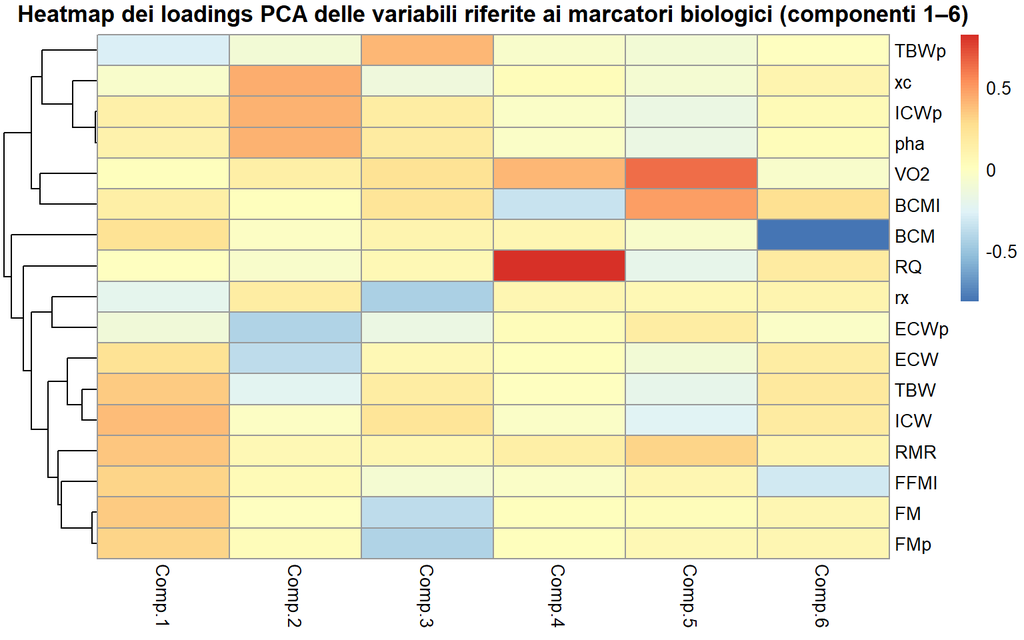

### Visualizzazione della varianza totale spiegata da ciascuna componente principale

```
## Importance of components:
##                           Comp.1    Comp.2    Comp.3     Comp.4     Comp.5
## Standard deviation     2.2717888 2.1252822 1.5809678 1.07836702 1.06400160
## Proportion of Variance 0.3035897 0.2656955 0.1470270 0.06840444 0.06659408
## Cumulative Proportion  0.3035897 0.5692852 0.7163122 0.78471665 0.85131073
##                            Comp.6     Comp.7     Comp.8     Comp.9     Comp.10
## Standard deviation     0.88433289 0.80212273 0.75011654 0.51488113 0.395159507
## Proportion of Variance 0.04600263 0.03784711 0.03309852 0.01559427 0.009185355
## Cumulative Proportion  0.89731336 0.93516047 0.96825899 0.98385326 0.993038614
##                            Comp.11      Comp.12      Comp.13      Comp.14
## Standard deviation     0.310333802 0.1056321999 0.0733202763 0.0571529671
## Proportion of Variance 0.005665122 0.0006563625 0.0003162272 0.0001921448
## Cumulative Proportion  0.998703736 0.9993600981 0.9996763253 0.9998684701
##                             Comp.15      Comp.16      Comp.17
## Standard deviation     3.800125e-02 2.753579e-02 5.804637e-03
## Proportion of Variance 8.494675e-05 4.460117e-05 1.981989e-06
## Cumulative Proportion  9.999534e-01 9.999980e-01 1.000000e+00
```

### Screegraph

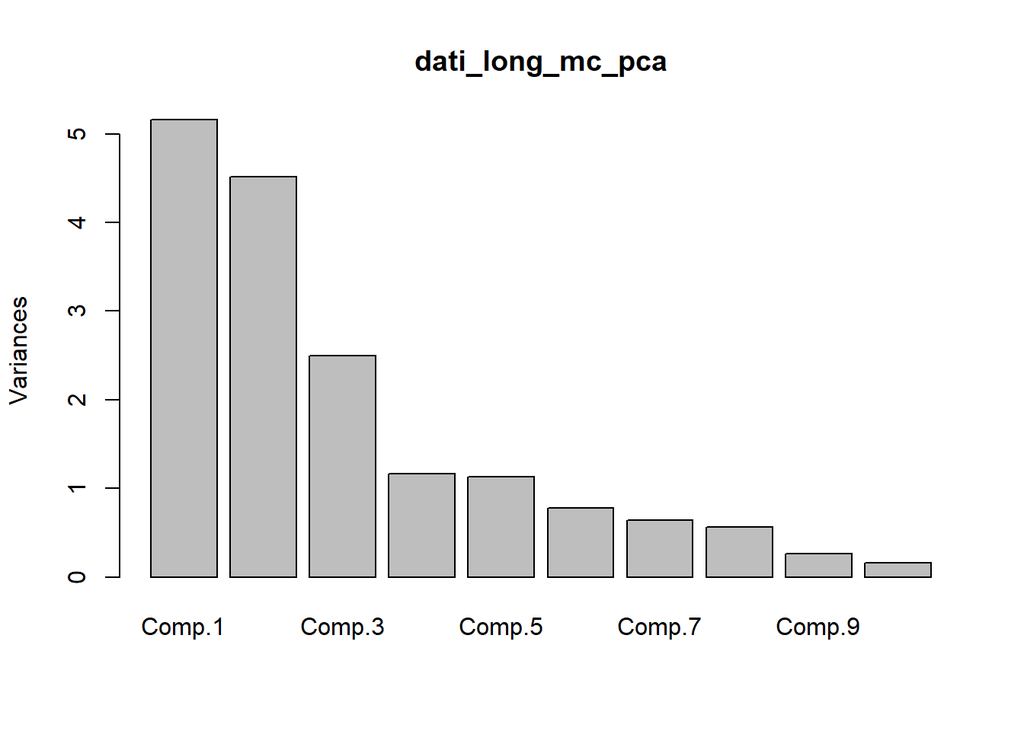

Si sceglie il numero minimo di componenti che spiegano abbastanza varianza nei dati, evitando di includerne troppi (overfitting) o troppo pochi (perdita di informazione), segnuendo la regola del gomito. All’inizio, la varianza spiegata cala molto velocemente, dopo un certo punto il “gomito”, la riduzione nella varianza spiegata diventa più lenta e graduale. Il “gomito” è il punto dopo il quale aggiungere ulteriori componenti non porta grandi miglioramenti.Il numero di componenti prima del gomito è quello che conviene mantenere. Scegliamo di considerare solo le prime 3 componenti principali, perché sono quelle che spiegano la maggior parte della varianza totale.

Per valutare quanto ogni variabile contribuisce alla spiegazione complessiva della varianza considerata dalle prime tre componenti principali, consideriamo l’indice di contributo alla varianza totale spiegata.

L’indice di contributo per la variabile $j$ è definito come:
$$\text{I}_j = \sum_{i=1}^{k}
\frac{(loading_{ji})^2}{\lambda_i}$$

I loadings Sono i coefficienti che collegano le variabili originali con le componenti principali; in sostanza descrivono come ogni variabile contribuisce alle componenti. In termini geometrici dicono quanto ogni variabile “pesa” in ogni nuovo asse. Gli autovalori rappresentano la varianza spiegata da ciascuna componente principale. Più l’autovalore è alto, più quella componente spiega una parte importante dell’informazione nei dati.

Si osserva nella tabella seguente quanto ogni variabile conrtibuisce alla spiegazione complessiva della varianza spiegata dalle prime 3 componenti principali

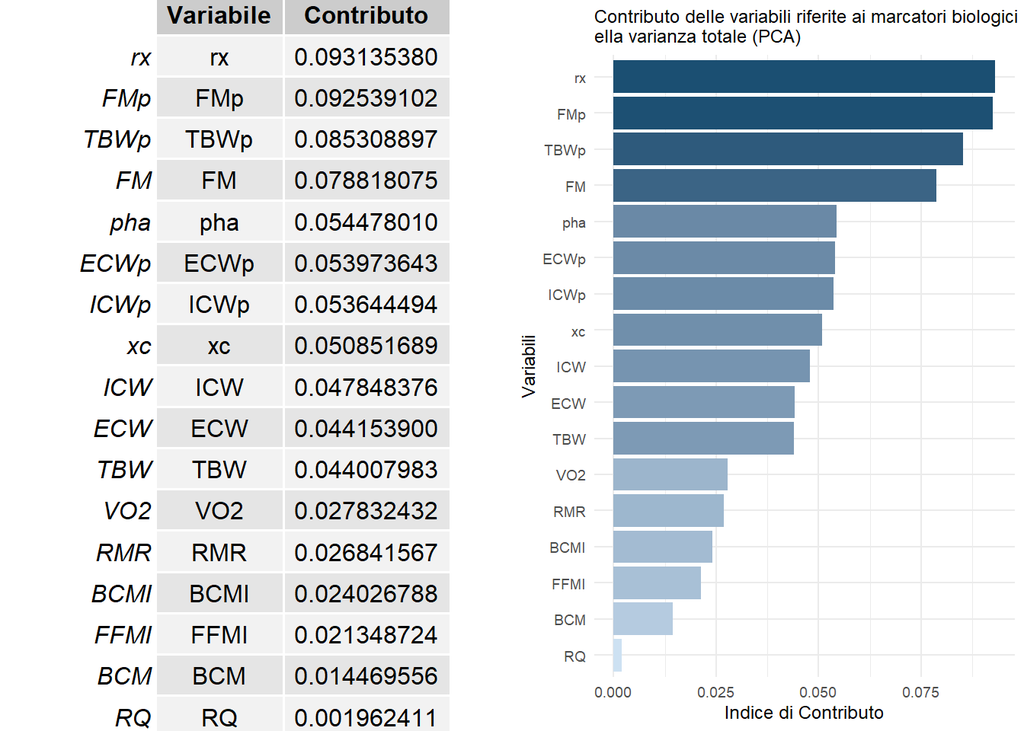

Si procede rimuovendo la variabile con un indice più basso e si rieffettua la pca per valutare pian piano quanto migliora la varianza spiegata dalla prima componente. Dopo la rimozione delle ultime sei variabili ( “RQ”, “BCM”,“FFMI”, “BCMI”, “RMR”, “VO2”)) ci si accorge che la prima componente riesce a spiegare circa il 40% della variabilità totale, considerando invece anche la seconda componente principale riusciremmo a spiegare circa il 70% della variabilità totale, che rappresenta un ottimo risultato.

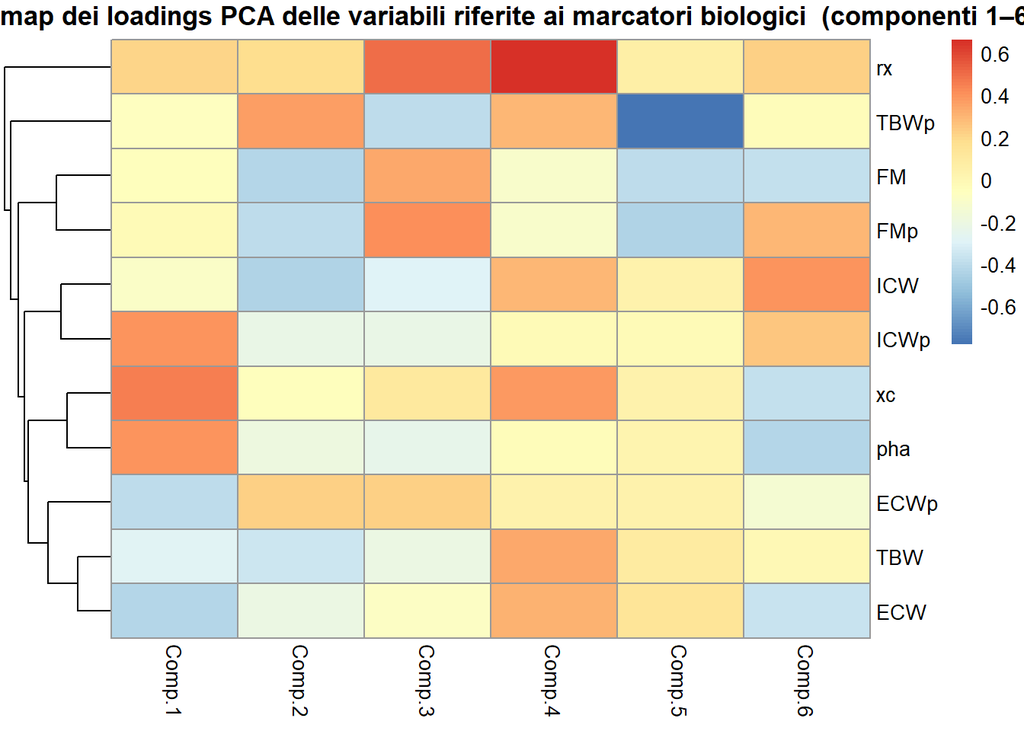

### Visualizzazione della varianza totale spiegata da ciascuna componente principale

```
## Importance of components:
##                           Comp.1    Comp.2    Comp.3     Comp.4     Comp.5
## Standard deviation     2.1055766 1.9518316 1.5121351 0.56451944 0.35783528
## Proportion of Variance 0.4030411 0.3463315 0.2078684 0.02897111 0.01164055
## Cumulative Proportion  0.4030411 0.7493727 0.9572411 0.98621217 0.99785273
##                             Comp.6       Comp.7       Comp.8       Comp.9
## Standard deviation     0.107655291 0.0757703865 0.0614813013 0.0407930234
## Proportion of Variance 0.001053606 0.0005219229 0.0003436319 0.0001512792
## Cumulative Proportion  0.998906333 0.9994282561 0.9997718879 0.9999231671
##                             Comp.10      Comp.11
## Standard deviation     2.833143e-02 6.518634e-03
## Proportion of Variance 7.296997e-05 3.862963e-06
## Cumulative Proportion  9.999961e-01 1.000000e+00
```

### Screegraph

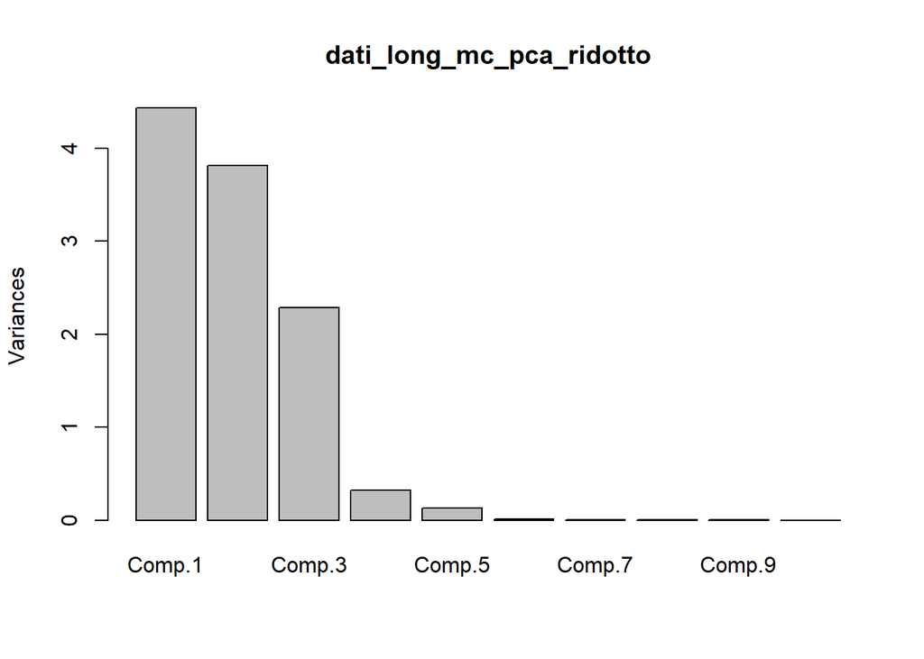

Scegliamo anche in questo caso in base alla regola del gomito, di considerare solo le prime 3 componenti principali, perché sono quelle che spiegano la maggior parte della varianza totale

Si osserva nella tabella seguente quanto ogni variabile contribuisce alla spiegazione complessiva della varianza spiegata dalle prime 3 componenti principali

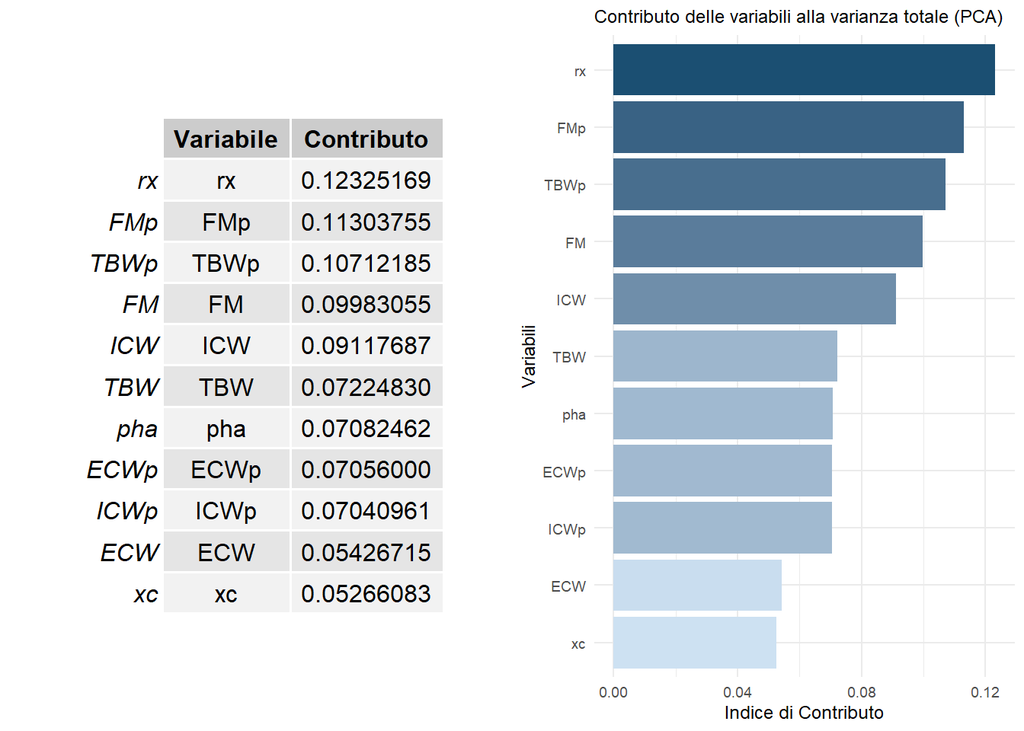

### PCA sulle variabili riferite alla forza fisica

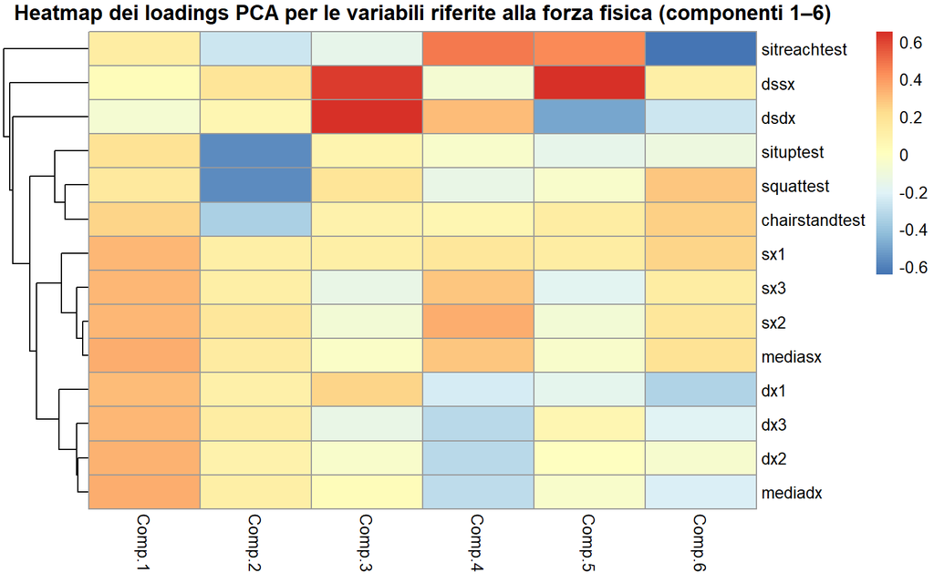

### Visualizzazione della varianza totale spiegata da ciascuna componente principale

```
## Importance of components:
##                           Comp.1    Comp.2     Comp.3     Comp.4     Comp.5
## Standard deviation     2.6638751 1.2769980 1.14536133 1.04914089 0.97336697
## Proportion of Variance 0.5068736 0.1164803 0.09370376 0.07862119 0.06767452
## Cumulative Proportion  0.5068736 0.6233539 0.71705764 0.79567883 0.86335335
##                            Comp.6     Comp.7     Comp.8     Comp.9     Comp.10
## Standard deviation     0.84615022 0.65333890 0.53017524 0.45350455 0.330108839
## Proportion of Variance 0.05114073 0.03048941 0.02007756 0.01469046 0.007783703
## Cumulative Proportion  0.91449408 0.94498348 0.96506104 0.97975150 0.987535199
##                            Comp.11     Comp.12      Comp.13      Comp.14
## Standard deviation     0.311840293 0.277961954 2.815646e-08 2.018772e-08
## Proportion of Variance 0.006946026 0.005518775 5.662760e-17 2.911029e-17
## Cumulative Proportion  0.994481225 1.000000000 1.000000e+00 1.000000e+00
```

### Screegraph

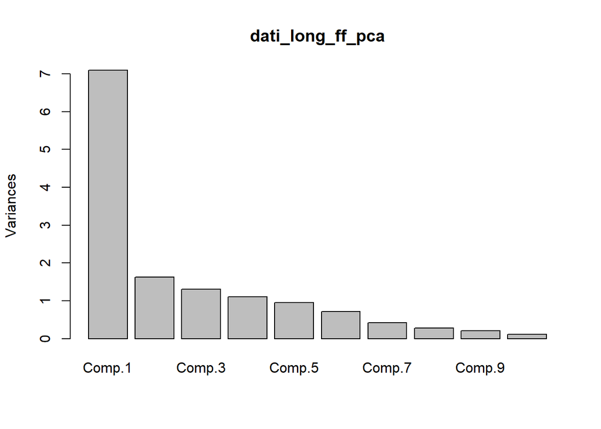

# Grafico relazione tra PC1(A) e PC1(B)

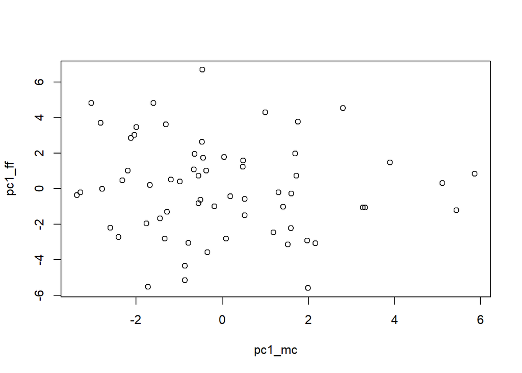

Si osserva una dispersione molto ampia che non ci permette di confermare la presenza di una correlazione tra le due componenti.

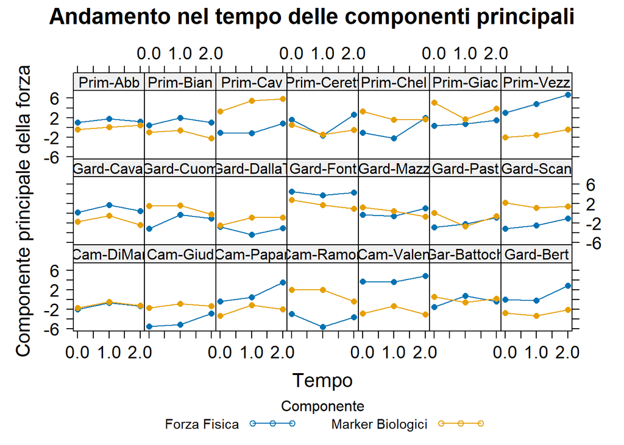

### Distribuzioni KPI per tempo

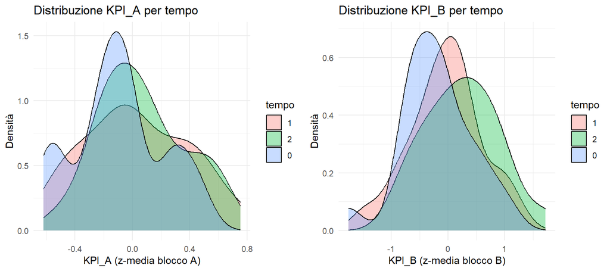

### Scatter A vs B per tempo

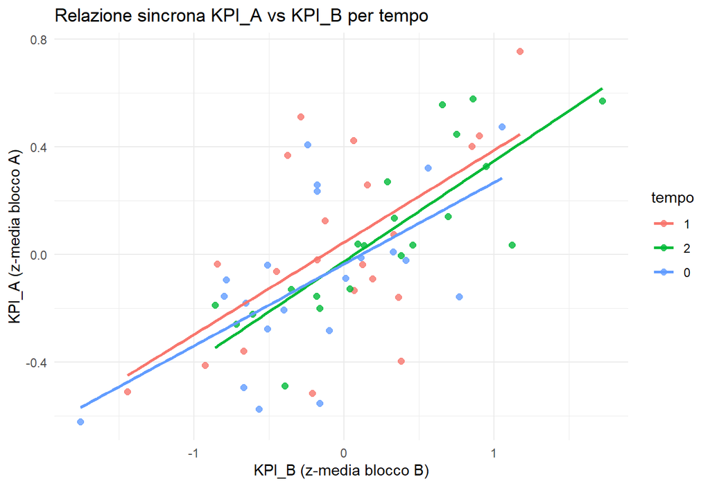

Pendenza positiva, c’è comunicazione tra i blocchi, ma si evidenziano nuvole larghe ⇒ **relazione moderata**, non stretta.

### Spaghetti per soggetto

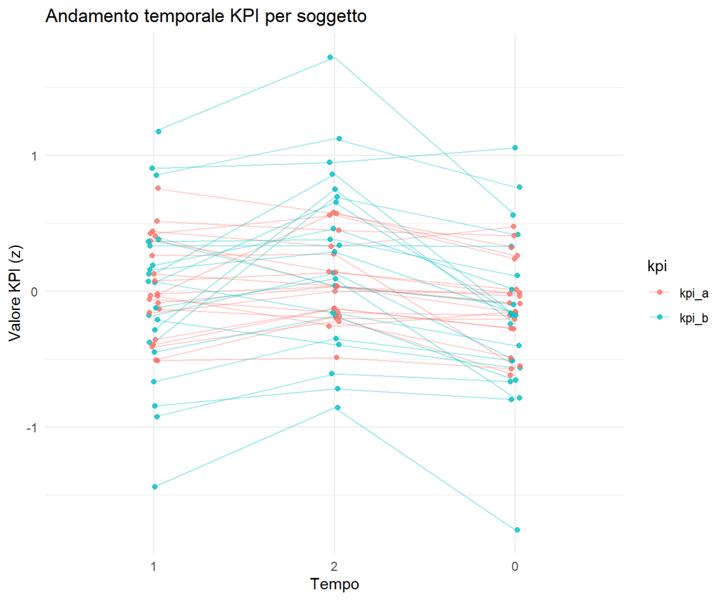

C’è eterogeneità tra soggetti: in alcuni A e B sono **paralleli**, in altri **divergono**. Un’informazione molto utile suggerita da questo grafico, è rappresentata dalla maggiore stabilità (minore variabilità) nei tre tempi dei valori delle variabili riferite al gruppo A ( marcatori clinici) per ogni soggetto rispetto alla maggiore variabilità dei valori nei tre tempi delle variabili riferiteal gruppo B (performance fisica) per ogni soggetto. I DAti sono standardizzati pertanto e diverse unità di misura dei due gRuppi di variabili non influenzano i risultati di questa informazione.

### Bland–Altman grezzo

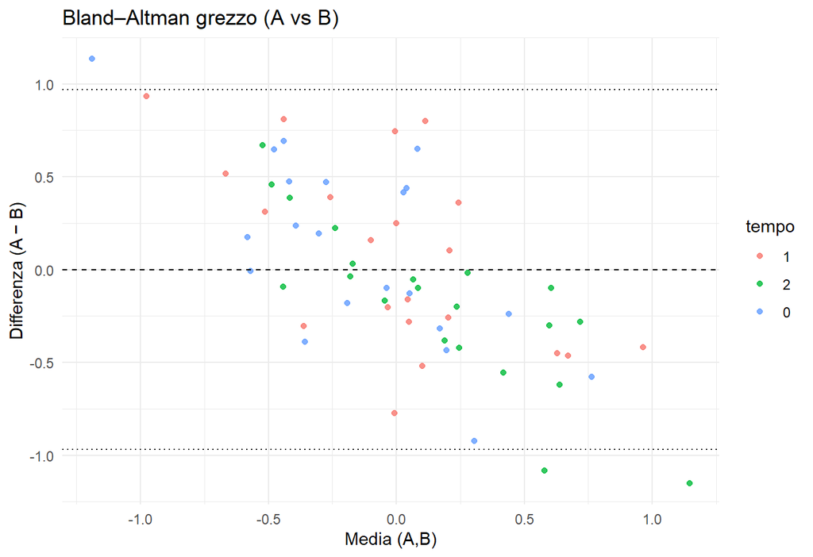

### Modello misto sincrono

Modello:

$$\text{KPI\_A}_{it} = \beta_0 + \beta_B\,\text{KPI\_B}_{it} +
\boldsymbol{\beta}_X^\top \mathbf{X}_{it} + \gamma_{t} + u_{0i} +
\varepsilon_{it},$$

con $u_{0i}\sim \mathcal{N}(0,\sigma_u^2)$ (random intercept per paziente).

```
## Linear mixed model fit by REML. t-tests use Satterthwaite's method [
## lmerModLmerTest]
## Formula: form_base
##    Data: dati_proc
##
## REML criterion at convergence: 8.8
##
## Scaled residuals:
##     Min      1Q  Median      3Q     Max
## -1.5846 -0.5970 -0.0951  0.5243  1.9384
##
## Random effects:
##  Groups   Name        Variance Std.Dev.
##  paziente (Intercept) 0.01354  0.1164
##  Residual             0.02011  0.1418
## Number of obs: 63, groups:  paziente, 21
##
## Fixed effects:
##                           Estimate Std. Error         df t value Pr(>|t|)
## (Intercept)             -1.395e+00  4.738e-01  3.873e+01  -2.946  0.00543 **
## kpi_b                    7.685e-02  6.756e-02  4.549e+01   1.138  0.26128
## tempo1                   6.142e-02  5.194e-02  4.052e+01   1.182  0.24390
## tempo2                   3.286e-02  5.571e-02  4.550e+01   0.590  0.55828
## sintomo_1Iperattività   -3.030e-01  2.369e-01  1.235e+01  -1.279  0.22440
## sintomo_1Restrizione c. -1.954e-01  1.607e-01  1.323e+01  -1.216  0.24523
## sintomo_2Iperattività   -1.607e-01  9.703e-02  1.549e+01  -1.657  0.11770
## sintomo_2null           -4.698e-01  1.793e-01  1.232e+01  -2.620  0.02198 *
## arto_domsx              -2.077e-02  9.465e-02  1.235e+01  -0.219  0.82989
## sessoM                   3.856e-01  2.123e-01  2.219e+01   1.816  0.08289 .
## bmi                      1.085e-01  1.982e-02  3.735e+01   5.471 3.18e-06 ***
## mkcal                   -1.706e-05  1.766e-04  4.893e+01  -0.097  0.92343
## variazionemenusi         4.743e-02  6.456e-02  4.559e+01   0.735  0.46633
## eta                     -1.039e-02  4.755e-03  1.464e+01  -2.185  0.04555 *
## ---
## Signif. codes:  0 '***' 0.001 '**' 0.01 '*' 0.05 '.' 0.1 ' ' 1
## fit warnings:
## fixed-effect model matrix is rank deficient so dropping 1 column / coefficient
```

```
##            R2m       R2c
## [1,] 0.7134415 0.8287589
```

Iperattività si riferisce alla componente comportamentale tipica di alcuni pazienti con anoressia, che manifestano attività fisica e motoria eccessiva (camminare molto, fare esercizio in modo compulsivo, incapacità di stare fermi). Restrizione, indica la modalità restrittiva della malattia, cioè la riduzione volontaria e significativa dell’apporto calorico (restrizione alimentare), tipica del sottotipo restrittivo di anoressia nervosa. Null probabilmente una categoria di riferimento o condizione in cui non sono presenti quei sintomi specifici.

Le evidenze più solide sono per il BMI e, in misura minore, per l’età.

L’effetto sincrono del KPI (kpi_b) non risulta significativo, suggerendo che la dinamica temporale potrebbe essere più complessa o richiedere un campione maggiore.